# a-guide-to-imbalance-distribution-problem-in-ml

[figure not shown]

## What is Imbalance distribution in Machine Learning?

This problem generally occurs in classification. In general when classes are not represented equally then we call it imbalance distribution. In real life maximum problem we face are imbalance problem like frud detection, disease detection, spam filtering, click prediction etc. In frud detection dataset `not fraud` samples are lot more than `fraud`. It creats a imbalance. Let's visualize what imbalace distribution looks like using `ucl-statistics` dataset.

```
Original values in ucl data: Counter({0: 686, 1: 28})
```

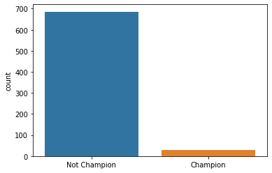

```python
import numpy as np
import pandas as pd
import matplotlib.pyplot as plt
import seaborn as sns
from collections import Counter
#ignore all warnings
import warnings
warnings.filterwarnings('ignore')

df = pd.read_csv('../input/ucl-statistics/ucl_stats.csv')
#creating x and y matrix of features
x1 = df.iloc[:, 2: -1]
y1 = df.iloc[:, -1]
print("Original values in ucl data: %s" % Counter(y1))

fig = sns.countplot(x = 'champions', data = df)
fig.set_xticklabels(labels=['Not Champion', 'Champion'])
plt.xlabel('');
```

```
1. Slight imbalance

2. Severe imbalance
```

#### Slight imbalance:

When the ratio of two sample is 6:4 in trainning set then the dataset is slightly imbalance.

#### Severe imbalance:

When the ration is 100:1 or 1000:1 or even more than it is severely imbalance.

## What happens when we apply ML on Imbalanced dataset!

```python
#splitting to train and test set
from sklearn.model_selection import train_test_split
x_train, x_test, y_train, y_test = train_test_split(x1, y1, test_size = 0.25, random_state = 7)

from sklearn.ensemble import RandomForestClassifier
clf = RandomForestClassifier(random_state = 31)

# Fit random hyperparameter search model
clf.fit(x_train, y_train)
score = clf.score(x_test, y_test)

print("Model accuracy in ucl data without dealing with Imbalance problem is: " + str(round((score * 100), 2)) + '%')
```

```
Model accuracy in ucl data without dealing with Imbalance problem is: 97.21%
```

But this is no what we desier. Let's first see the classification report.

```python
#making prediction
y_preds = clf.predict(x_test)
from sklearn.metrics import classification_report
print(classification_report(y_test, y_preds))
```

```
              precision    recall  f1-score   support

           0       0.97      1.00      0.99       172
           1       1.00      0.29      0.44         7

    accuracy                           0.97       179
   macro avg       0.99      0.64      0.72       179
weighted avg       0.97      0.97      0.96       179
```

#### Why this is happening?

Because most machine learning algorithms work best when the number of samples in each class are about equal. This is because most algorithms are designed to maximize accuracy and reduce error.

#### How can we solve this?

Ther are some common ways:

```
1. Collecting more data

2. Trying Different Perspective

3. Sampling
```

#### Collecting more data:

Collecting more data could balance any dataset. So, first you should try collect more data if it is possible.

#### Sampling:

There are three types of sampling.

```
 1. Under-sampling

 2. Over-sampling

 3. Combine-sampling
```

#### Under-sampling:

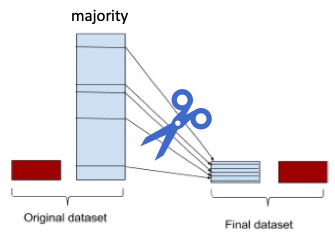

The above figure of under-sampling is self explanetory. In this process we cut out some samples from the majority class and it balances the dataset. But this technique is not suggested for small severe imbalanced dataset because important samples can be removed and the model will perform badly on both class but this technique can be useful for very large dataset.

Let's see udersampling in action using `creditcard` dataset.

```
Original values in creditcard data: Counter({0: 284315, 1: 492})
Values after applying undersampling: Counter({0: 492, 1: 492})
```

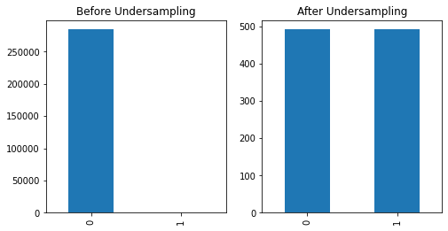

```python
df2 = pd.read_csv('../input/creditcardfraud/creditcard.csv')

x2 = df2.drop("Class",axis=1)
y2 = df2['Class']

print("Original values in creditcard data: %s" % Counter(y2))

#applying under sampling
from imblearn.under_sampling import RandomUnderSampler
random_under_sample = RandomUnderSampler(random_state=42)
x_new, y_new = random_under_sample.fit_resample(x2, y2)
print("Values after applying undersampling: %s" % Counter(y_new))

#plotting
fig, axarr = plt.subplots(1, 2, figsize = (8, 4))
df2.Class.value_counts().plot.bar(ax=axarr[0])
y_new.value_counts().plot.bar(ax=axarr[1])
axarr[0].set_title("Before Undersampling")
axarr[1].set_title("After Undersampling");
```

There is a parametere called `sampling_strategy` by which we can obtain desired ratio of samples. Let's see this in action..

```
Original values in creditcard data: Counter({0: 284315, 1: 492})
Values after applying undersampling with ration 0.5: Counter({0: 984, 1: 492})
```

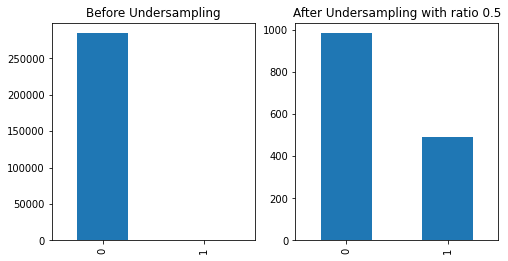

```python
print("Original values in creditcard data: %s" % Counter(y2))

random_under_sample = RandomUnderSampler(sampling_strategy = 0.5, random_state=42)
x_with_ratio, y_with_ratio = random_under_sample.fit_resample(x2, y2)
print("Values after applying undersampling with ration 0.5: %s" % Counter(y_with_ratio))

#plotting
fig, axarr = plt.subplots(1, 2, figsize = (8, 4))
df2.Class.value_counts().plot.bar(ax=axarr[0])
y_with_ratio.value_counts().plot.bar(ax=axarr[1])
axarr[0].set_title("Before Undersampling")
axarr[1].set_title("After Undersampling with ratio 0.5");
```

There are other under-sampling algorithms you can find [here](https://imbalanced-learn.org/stable/references/under_sampling.html)

#### Over-sampling:

Over-sampling uses various techniques to increases number of samples in minority class. Under-sampling reduces samples in majority class and over-sampling increases samples in minority class. Over-sampling is more reliable over under-sampling.

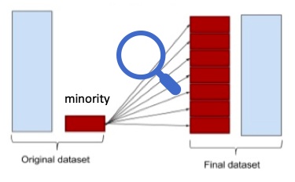

The best technique for oversampling is SMOTE(Synthetic Minority Oversampling Technique). It uses K-neighbors methods to detemine new samples. You can learn more about Smote [here](https://imbalanced-learn.org/stable/references/generated/imblearn.over_sampling.SMOTE.html).

Let's balance our `ucl-stats` dataset using SMOTE.

```
Original values in ucl data: Counter({0: 686, 1: 28})
Values after applying oversampling: Counter({1: 686, 0: 686})
```

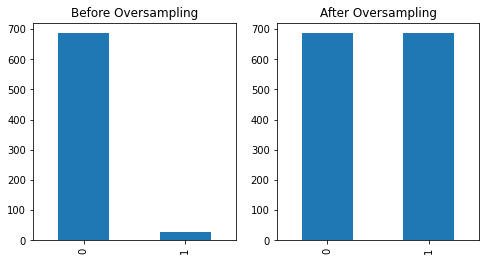

```python
from imblearn.over_sampling import SMOTE

#applying smote
smote = SMOTE()
x_sm, y_sm = smote.fit_resample(x1, y1)

print("Original values in ucl data: %s" % Counter(y1))

print("Values after applying oversampling: %s" % Counter(y_sm))

#plotting
fig, axarr = plt.subplots(1, 2, figsize = (8, 4))
df.champions.value_counts().plot.bar(ax=axarr[0])
y_sm.value_counts().plot.bar(ax=axarr[1])
axarr[0].set_title("Before Oversampling")
axarr[1].set_title("After Oversampling");
```

[figure not shown]

```python
#applying ml on balanced data
from sklearn.model_selection import train_test_split
x_train, x_test, y_train, y_test = train_test_split(x_sm, y_sm, test_size = 0.25, random_state = 7)

from sklearn.ensemble import RandomForestClassifier
clf = RandomForestClassifier(random_state = 31)

# Fit random hyperparameter search model
clf.fit(x_train, y_train)
score = clf.score(x_test, y_test)

print("Model accuracy in ucl data after applying SMOTE technique is: " + str(round((score * 100), 2)) + '%')
```

```
Model accuracy in ucl data after applying SMOTE technique is: 98.25%
```

```python
y_preds = clf.predict(x_test)
from sklearn.metrics import classification_report
print(classification_report(y_test, y_preds))
```

```
              precision    recall  f1-score   support

           0       1.00      0.97      0.98       175
           1       0.97      1.00      0.98       168

    accuracy                           0.98       343
   macro avg       0.98      0.98      0.98       343
weighted avg       0.98      0.98      0.98       343
```

There are some other algorithms for over-sampling like SMOTENC, ADASYN, BorderlineSMOTE etc. You can find detail about all of them [here](https://imbalanced-learn.org/stable/references/over_sampling.html). You can also check out this paper [SMOTE: Synthetic Minority Over-sampling Technique](https://arxiv.org/pdf/1106.1813.pdf).

#### Combining Over-sampling and Under-sampling:

SMOTE technique sometime generate noisy samples. This problem can be solved using combined algorithms like SMOTEENN and SMOTETomek. SMOTEENN is the combination of SMOTE(Synthetic Minority Oversampling Technique) and ENN(Edited Nearest Neighbours). This algorithm use SMOTE to increase samples and use ENN to remove noisy samples.

```
Original values in ucl data: Counter({0: 686, 1: 28})
Values after applying combinesampling: Counter({1: 670, 0: 628})
```

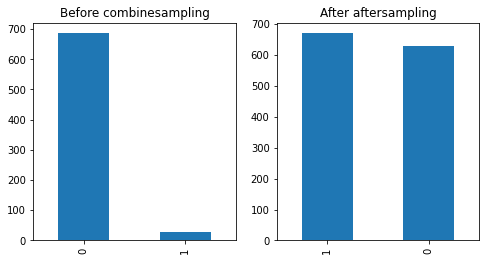

```python
from imblearn.combine import SMOTEENN

sme = SMOTEENN(random_state=42)
x_res, y_res = sme.fit_resample(x1, y1)

print("Original values in ucl data: %s" % Counter(y1))

print("Values after applying combinesampling: %s" % Counter(y_res))

#plotting
fig, axarr = plt.subplots(1, 2, figsize = (8, 4))
df.champions.value_counts().plot.bar(ax=axarr[0])
y_res.value_counts().plot.bar(ax=axarr[1])
axarr[0].set_title("Before combinesampling")
axarr[1].set_title("After aftersampling");
```

Let's apply machine learning on this..

```python
from sklearn.model_selection import train_test_split
x_train, x_test, y_train, y_test = train_test_split(x_res, y_res, test_size = 0.25, random_state = 7)

from sklearn.ensemble import RandomForestClassifier
clf = RandomForestClassifier(random_state = 31)

# Fit random hyperparameter search model
clf.fit(x_train, y_train)
score = clf.score(x_test, y_test)

print("Model accuracy after applying Combine-sampling technique is: " + str(round((score * 100), 2)) + '%')
```

```
Model accuracy after applying Combine-sampling technique is: 98.77%
```

```python
y_preds = clf.predict(x_test)
from sklearn.metrics import classification_report
print(classification_report(y_test, y_preds))
```

```
              precision    recall  f1-score   support

           0       1.00      0.97      0.99       160
           1       0.98      1.00      0.99       165

    accuracy                           0.99       325
   macro avg       0.99      0.99      0.99       325
weighted avg       0.99      0.99      0.99       325
```

#### Conclusion:

1. Imbalanced classification is the problem of classification when there is an unequal distribution of classes in the training dataset.
2. If possible try gather more data.
3. Under-sampling can be applied on large dataset.
4. Over-sampling is the best choice for small and medium datasets.
5. Must use classification report or cinfusion matrices to check result with imbalance dataset.
6. Try using tree based algorithms.